# Risk Factor Analysis

## Outcome Variable

**Outcome Variable:** haz

## Predictor Variables

**Intervention Variable:** predfeed3

**Adjustment Set:**

- arm
- sex
- month
- brthmon
- W_mage
- meducyrs
- feducyrs
- hhwealth_quart
- hfoodsec
- W_mhtcm
- vagbrth
- W_gagebrth
- W_birthwt
- W_birthlen
- W_nrooms
- W_nchldlt5
- W_parity
- impfloor
- impsan
- safeh20
- delta_W_mage
- delta_meducyrs
- delta_feducyrs
- delta_hhwealth_quart
- delta_hfoodsec
- delta_W_mhtcm
- delta_vagbrth
- delta_W_gagebrth
- delta_W_birthwt
- delta_W_birthlen
- delta_W_nrooms
- delta_W_nchldlt5
- delta_W_parity
- delta_impfloor
- delta_impsan
- delta_safeh20

## Stratifying Variables

The analysis was stratified on these variable(s):

- agecat
- studyid
- country

## Data Summary

| agecat | studyid | country | predfeed3 | n_cell | n |
| --- | --- | --- | --- | --- | --- |
| Birth | ki0047075b-MAL-ED | BANGLADESH | 1 | 205 | 240 |
| Birth | ki0047075b-MAL-ED | BANGLADESH | 0 | 35 | 240 |
| Birth | ki0047075b-MAL-ED | BRAZIL | 1 | 101 | 185 |
| Birth | ki0047075b-MAL-ED | BRAZIL | 0 | 84 | 185 |
| Birth | ki0047075b-MAL-ED | INDIA | 1 | 152 | 196 |
| Birth | ki0047075b-MAL-ED | INDIA | 0 | 44 | 196 |
| Birth | ki0047075b-MAL-ED | NEPAL | 1 | 99 | 171 |
| Birth | ki0047075b-MAL-ED | NEPAL | 0 | 72 | 171 |
| Birth | ki0047075b-MAL-ED | PERU | 1 | 183 | 272 |
| Birth | ki0047075b-MAL-ED | PERU | 0 | 89 | 272 |
| Birth | ki0047075b-MAL-ED | SOUTH AFRICA | 1 | 87 | 233 |
| Birth | ki0047075b-MAL-ED | SOUTH AFRICA | 0 | 146 | 233 |
| Birth | ki0047075b-MAL-ED | TANZANIA, UNITED REPUBLIC OF | 1 | 50 | 119 |
| Birth | ki0047075b-MAL-ED | TANZANIA, UNITED REPUBLIC OF | 0 | 69 | 119 |
| Birth | ki1000109-EE | PAKISTAN | 1 | 2 | 2 |
| Birth | ki1000109-EE | PAKISTAN | 0 | 0 | 2 |
| Birth | kiGH5241-JiVitA-3 | BANGLADESH | 1 | 16832 | 18710 |
| Birth | kiGH5241-JiVitA-3 | BANGLADESH | 0 | 1878 | 18710 |
| Birth | kiGH5241-JiVitA-4 | BANGLADESH | 1 | 37 | 40 |
| Birth | kiGH5241-JiVitA-4 | BANGLADESH | 0 | 3 | 40 |
| 6 months | ki0047075b-MAL-ED | BANGLADESH | 1 | 203 | 237 |
| 6 months | ki0047075b-MAL-ED | BANGLADESH | 0 | 34 | 237 |
| 6 months | ki0047075b-MAL-ED | BRAZIL | 1 | 116 | 209 |
| 6 months | ki0047075b-MAL-ED | BRAZIL | 0 | 93 | 209 |
| 6 months | ki0047075b-MAL-ED | INDIA | 1 | 178 | 233 |
| 6 months | ki0047075b-MAL-ED | INDIA | 0 | 55 | 233 |
| 6 months | ki0047075b-MAL-ED | NEPAL | 1 | 132 | 233 |
| 6 months | ki0047075b-MAL-ED | NEPAL | 0 | 101 | 233 |
| 6 months | ki0047075b-MAL-ED | PERU | 1 | 183 | 270 |
| 6 months | ki0047075b-MAL-ED | PERU | 0 | 87 | 270 |
| 6 months | ki0047075b-MAL-ED | SOUTH AFRICA | 1 | 86 | 248 |
| 6 months | ki0047075b-MAL-ED | SOUTH AFRICA | 0 | 162 | 248 |
| 6 months | ki0047075b-MAL-ED | TANZANIA, UNITED REPUBLIC OF | 1 | 91 | 240 |
| 6 months | ki0047075b-MAL-ED | TANZANIA, UNITED REPUBLIC OF | 0 | 149 | 240 |
| 6 months | ki1000109-EE | PAKISTAN | 1 | 346 | 371 |
| 6 months | ki1000109-EE | PAKISTAN | 0 | 25 | 371 |
| 6 months | ki1113344-GMS-Nepal | NEPAL | 1 | 379 | 458 |
| 6 months | ki1113344-GMS-Nepal | NEPAL | 0 | 79 | 458 |
| 6 months | kiGH5241-JiVitA-3 | BANGLADESH | 1 | 14797 | 16281 |
| 6 months | kiGH5241-JiVitA-3 | BANGLADESH | 0 | 1484 | 16281 |
| 6 months | kiGH5241-JiVitA-4 | BANGLADESH | 1 | 77 | 89 |
| 6 months | kiGH5241-JiVitA-4 | BANGLADESH | 0 | 12 | 89 |
| 24 months | ki0047075b-MAL-ED | BANGLADESH | 1 | 178 | 208 |
| 24 months | ki0047075b-MAL-ED | BANGLADESH | 0 | 30 | 208 |
| 24 months | ki0047075b-MAL-ED | BRAZIL | 1 | 98 | 169 |
| 24 months | ki0047075b-MAL-ED | BRAZIL | 0 | 71 | 169 |
| 24 months | ki0047075b-MAL-ED | INDIA | 1 | 170 | 225 |
| 24 months | ki0047075b-MAL-ED | INDIA | 0 | 55 | 225 |
| 24 months | ki0047075b-MAL-ED | NEPAL | 1 | 128 | 225 |
| 24 months | ki0047075b-MAL-ED | NEPAL | 0 | 97 | 225 |
| 24 months | ki0047075b-MAL-ED | PERU | 1 | 137 | 199 |
| 24 months | ki0047075b-MAL-ED | PERU | 0 | 62 | 199 |
| 24 months | ki0047075b-MAL-ED | SOUTH AFRICA | 1 | 81 | 232 |
| 24 months | ki0047075b-MAL-ED | SOUTH AFRICA | 0 | 151 | 232 |
| 24 months | ki0047075b-MAL-ED | TANZANIA, UNITED REPUBLIC OF | 1 | 79 | 210 |
| 24 months | ki0047075b-MAL-ED | TANZANIA, UNITED REPUBLIC OF | 0 | 131 | 210 |
| 24 months | ki1113344-GMS-Nepal | NEPAL | 1 | 336 | 404 |
| 24 months | ki1113344-GMS-Nepal | NEPAL | 0 | 68 | 404 |
| 24 months | kiGH5241-JiVitA-3 | BANGLADESH | 1 | 7520 | 8341 |
| 24 months | kiGH5241-JiVitA-3 | BANGLADESH | 0 | 821 | 8341 |
| 24 months | kiGH5241-JiVitA-4 | BANGLADESH | 1 | 137 | 152 |
| 24 months | kiGH5241-JiVitA-4 | BANGLADESH | 0 | 15 | 152 |

The following strata were considered:

- agecat: 24 months, studyid: ki0047075b-MAL-ED, country: BANGLADESH
- agecat: 24 months, studyid: ki0047075b-MAL-ED, country: BRAZIL
- agecat: 24 months, studyid: ki0047075b-MAL-ED, country: INDIA
- agecat: 24 months, studyid: ki0047075b-MAL-ED, country: NEPAL
- agecat: 24 months, studyid: ki0047075b-MAL-ED, country: PERU
- agecat: 24 months, studyid: ki0047075b-MAL-ED, country: SOUTH AFRICA
- agecat: 24 months, studyid: ki0047075b-MAL-ED, country: TANZANIA, UNITED REPUBLIC OF
- agecat: 24 months, studyid: ki1113344-GMS-Nepal, country: NEPAL
- agecat: 24 months, studyid: kiGH5241-JiVitA-3, country: BANGLADESH
- agecat: 24 months, studyid: kiGH5241-JiVitA-4, country: BANGLADESH
- agecat: 6 months, studyid: ki0047075b-MAL-ED, country: BANGLADESH
- agecat: 6 months, studyid: ki0047075b-MAL-ED, country: BRAZIL
- agecat: 6 months, studyid: ki0047075b-MAL-ED, country: INDIA
- agecat: 6 months, studyid: ki0047075b-MAL-ED, country: NEPAL
- agecat: 6 months, studyid: ki0047075b-MAL-ED, country: PERU
- agecat: 6 months, studyid: ki0047075b-MAL-ED, country: SOUTH AFRICA
- agecat: 6 months, studyid: ki0047075b-MAL-ED, country: TANZANIA, UNITED REPUBLIC OF
- agecat: 6 months, studyid: ki1000109-EE, country: PAKISTAN
- agecat: 6 months, studyid: ki1113344-GMS-Nepal, country: NEPAL
- agecat: 6 months, studyid: kiGH5241-JiVitA-3, country: BANGLADESH
- agecat: 6 months, studyid: kiGH5241-JiVitA-4, country: BANGLADESH
- agecat: Birth, studyid: ki0047075b-MAL-ED, country: BANGLADESH
- agecat: Birth, studyid: ki0047075b-MAL-ED, country: BRAZIL
- agecat: Birth, studyid: ki0047075b-MAL-ED, country: INDIA
- agecat: Birth, studyid: ki0047075b-MAL-ED, country: NEPAL
- agecat: Birth, studyid: ki0047075b-MAL-ED, country: PERU
- agecat: Birth, studyid: ki0047075b-MAL-ED, country: SOUTH AFRICA
- agecat: Birth, studyid: ki0047075b-MAL-ED, country: TANZANIA, UNITED REPUBLIC OF
- agecat: Birth, studyid: ki1000109-EE, country: PAKISTAN
- agecat: Birth, studyid: kiGH5241-JiVitA-3, country: BANGLADESH
- agecat: Birth, studyid: kiGH5241-JiVitA-4, country: BANGLADESH

### Dropped Strata

Some strata were dropped due to rare outcomes:

- agecat: Birth, studyid: ki1000109-EE, country: PAKISTAN
- agecat: Birth, studyid: kiGH5241-JiVitA-4, country: BANGLADESH

## Methods Detail

We’re interested in the causal parameters $E[Y_a]$ for all values of $a \in \mathcal{A}$. These parameters represent the mean outcome if, possibly contrary to fact, we intervened to set all units to have $A=a$. Under the randomization and positivity assumptions, these are identified by the statistical parameters $\psi_a=E_W[E_{Y|A,W}(Y|A=a,W)]$. In addition, we’re interested in the mean of $Y$, $E[Y]$ under no intervention (the observed mean). We will estimate these parameters by using SuperLearner to fit the relevant likelihood factors – $E_{Y|A,W}(Y|A=a,W)$ and $p(A=a|W)$, and then updating our likelihood fit using a joint TMLE.

For unadjusted analyses ($W=\{\}$), initial likelihoods were estimated using Lrnr_glm to estimate the simple $E(Y|A)$ and Lrnr_mean to estimate $p(A)$. For adjusted analyses, a small library containing Lrnr_glmnet, Lrnr_xgboost, and Lrnr_mean was used.

Having estimated these parameters, we will then use the delta method to estimate relative risks and attributable risks relative to a prespecified baseline level of $A$.

# Results Detail

## Results Plots

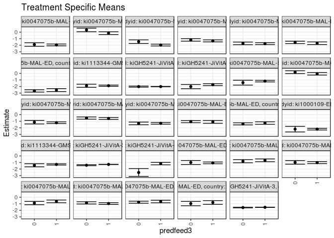

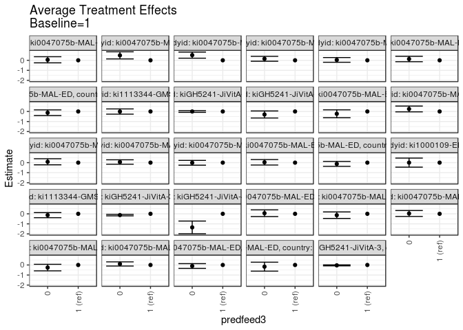

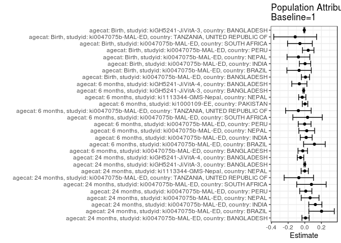

## Results Table

### Parameter: TSM

| agecat | studyid | country | intervention_level | baseline_level | estimate | ci_lower | ci_upper |
| --- | --- | --- | --- | --- | --- | --- | --- |
| Birth | ki0047075b-MAL-ED | BANGLADESH | 1 | NA | -1.0584253 | -1.2000390 | -0.9168116 |
| Birth | ki0047075b-MAL-ED | BANGLADESH | 0 | NA | -0.9988393 | -1.3000688 | -0.6976098 |
| Birth | ki0047075b-MAL-ED | BRAZIL | 1 | NA | -0.6671290 | -0.8780365 | -0.4562215 |
| Birth | ki0047075b-MAL-ED | BRAZIL | 0 | NA | -0.8043708 | -1.0494324 | -0.5593092 |
| Birth | ki0047075b-MAL-ED | INDIA | 1 | NA | -1.0134394 | -1.1684518 | -0.8584271 |
| Birth | ki0047075b-MAL-ED | INDIA | 0 | NA | -0.9810169 | -1.2528304 | -0.7092033 |
| Birth | ki0047075b-MAL-ED | NEPAL | 1 | NA | -0.6368276 | -0.8409073 | -0.4327478 |
| Birth | ki0047075b-MAL-ED | NEPAL | 0 | NA | -0.8949220 | -1.1454846 | -0.6443593 |
| Birth | ki0047075b-MAL-ED | PERU | 1 | NA | -0.9676922 | -1.1053140 | -0.8300705 |
| Birth | ki0047075b-MAL-ED | PERU | 0 | NA | -0.8658272 | -1.0385874 | -0.6930671 |
| Birth | ki0047075b-MAL-ED | SOUTH AFRICA | 1 | NA | -0.6528141 | -0.8516018 | -0.4540264 |
| Birth | ki0047075b-MAL-ED | SOUTH AFRICA | 0 | NA | -0.7565077 | -0.9099177 | -0.6030977 |
| Birth | ki0047075b-MAL-ED | TANZANIA, UNITED REPUBLIC OF | 1 | NA | -0.8056329 | -1.0902480 | -0.5210177 |
| Birth | ki0047075b-MAL-ED | TANZANIA, UNITED REPUBLIC OF | 0 | NA | -0.9740657 | -1.3044485 | -0.6436830 |
| Birth | kiGH5241-JiVitA-3 | BANGLADESH | 1 | NA | -1.5402391 | -1.5601666 | -1.5203115 |
| Birth | kiGH5241-JiVitA-3 | BANGLADESH | 0 | NA | -1.5767938 | -1.6283874 | -1.5252001 |
| 6 months | ki0047075b-MAL-ED | BANGLADESH | 1 | NA | -1.1767023 | -1.3010683 | -1.0523363 |
| 6 months | ki0047075b-MAL-ED | BANGLADESH | 0 | NA | -1.4095292 | -1.7822106 | -1.0368478 |
| 6 months | ki0047075b-MAL-ED | BRAZIL | 1 | NA | -0.0650190 | -0.2554021 | 0.1253641 |
| 6 months | ki0047075b-MAL-ED | BRAZIL | 0 | NA | 0.1841012 | -0.0335854 | 0.4017878 |
| 6 months | ki0047075b-MAL-ED | INDIA | 1 | NA | -1.2282728 | -1.3599515 | -1.0965941 |
| 6 months | ki0047075b-MAL-ED | INDIA | 0 | NA | -1.1433725 | -1.4146898 | -0.8720552 |
| 6 months | ki0047075b-MAL-ED | NEPAL | 1 | NA | -0.5795784 | -0.7238580 | -0.4352989 |
| 6 months | ki0047075b-MAL-ED | NEPAL | 0 | NA | -0.5181708 | -0.6899653 | -0.3463763 |
| 6 months | ki0047075b-MAL-ED | PERU | 1 | NA | -1.3215245 | -1.4507025 | -1.1923465 |
| 6 months | ki0047075b-MAL-ED | PERU | 0 | NA | -1.3363306 | -1.5376989 | -1.1349624 |
| 6 months | ki0047075b-MAL-ED | SOUTH AFRICA | 1 | NA | -1.0977509 | -1.3108641 | -0.8846378 |
| 6 months | ki0047075b-MAL-ED | SOUTH AFRICA | 0 | NA | -1.0636513 | -1.2277505 | -0.8995521 |
| 6 months | ki0047075b-MAL-ED | TANZANIA, UNITED REPUBLIC OF | 1 | NA | -1.2751461 | -1.4644403 | -1.0858518 |
| 6 months | ki0047075b-MAL-ED | TANZANIA, UNITED REPUBLIC OF | 0 | NA | -1.3996473 | -1.5617547 | -1.2375398 |
| 6 months | ki1000109-EE | PAKISTAN | 1 | NA | -2.2091002 | -2.3363937 | -2.0818068 |
| 6 months | ki1000109-EE | PAKISTAN | 0 | NA | -2.2071075 | -2.6400110 | -1.7742039 |
| 6 months | ki1113344-GMS-Nepal | NEPAL | 1 | NA | -1.2937275 | -1.3869220 | -1.2005330 |
| 6 months | ki1113344-GMS-Nepal | NEPAL | 0 | NA | -1.4268474 | -1.6607160 | -1.1929788 |
| 6 months | kiGH5241-JiVitA-3 | BANGLADESH | 1 | NA | -1.2927825 | -1.3161735 | -1.2693914 |
| 6 months | kiGH5241-JiVitA-3 | BANGLADESH | 0 | NA | -1.4202369 | -1.4968776 | -1.3435962 |
| 6 months | kiGH5241-JiVitA-4 | BANGLADESH | 1 | NA | -1.1689701 | -1.3565654 | -0.9813747 |
| 6 months | kiGH5241-JiVitA-4 | BANGLADESH | 0 | NA | -2.5221908 | -3.1200209 | -1.9243608 |
| 24 months | ki0047075b-MAL-ED | BANGLADESH | 1 | NA | -1.9486571 | -2.0912047 | -1.8061095 |
| 24 months | ki0047075b-MAL-ED | BANGLADESH | 0 | NA | -1.8966477 | -2.1660975 | -1.6271979 |
| 24 months | ki0047075b-MAL-ED | BRAZIL | 1 | NA | -0.1600193 | -0.3722596 | 0.0522210 |
| 24 months | ki0047075b-MAL-ED | BRAZIL | 0 | NA | 0.3305743 | 0.0544950 | 0.6066537 |
| 24 months | ki0047075b-MAL-ED | INDIA | 1 | NA | -1.9705145 | -2.1085522 | -1.8324769 |
| 24 months | ki0047075b-MAL-ED | INDIA | 0 | NA | -1.4559890 | -1.7289615 | -1.1830165 |
| 24 months | ki0047075b-MAL-ED | NEPAL | 1 | NA | -1.3335681 | -1.4863367 | -1.1807996 |
| 24 months | ki0047075b-MAL-ED | NEPAL | 0 | NA | -1.1837519 | -1.3734555 | -0.9940483 |
| 24 months | ki0047075b-MAL-ED | PERU | 1 | NA | -1.7562724 | -1.8987343 | -1.6138104 |
| 24 months | ki0047075b-MAL-ED | PERU | 0 | NA | -1.7170339 | -1.9189955 | -1.5150723 |
| 24 months | ki0047075b-MAL-ED | SOUTH AFRICA | 1 | NA | -1.6916602 | -1.8924444 | -1.4908759 |
| 24 months | ki0047075b-MAL-ED | SOUTH AFRICA | 0 | NA | -1.5633830 | -1.7452221 | -1.3815440 |
| 24 months | ki0047075b-MAL-ED | TANZANIA, UNITED REPUBLIC OF | 1 | NA | -2.5448607 | -2.7689893 | -2.3207320 |
| 24 months | ki0047075b-MAL-ED | TANZANIA, UNITED REPUBLIC OF | 0 | NA | -2.6697247 | -2.8421402 | -2.4973092 |
| 24 months | ki1113344-GMS-Nepal | NEPAL | 1 | NA | -1.8784913 | -1.9769336 | -1.7800490 |
| 24 months | ki1113344-GMS-Nepal | NEPAL | 0 | NA | -1.8852821 | -2.1269893 | -1.6435749 |
| 24 months | kiGH5241-JiVitA-3 | BANGLADESH | 1 | NA | -2.0108080 | -2.0396249 | -1.9819910 |
| 24 months | kiGH5241-JiVitA-3 | BANGLADESH | 0 | NA | -2.0116659 | -2.0976080 | -1.9257237 |
| 24 months | kiGH5241-JiVitA-4 | BANGLADESH | 1 | NA | -1.7163713 | -1.8606470 | -1.5720955 |
| 24 months | kiGH5241-JiVitA-4 | BANGLADESH | 0 | NA | -2.0163125 | -2.3366067 | -1.6960183 |

### Parameter: E(Y)

| agecat | studyid | country | intervention_level | baseline_level | estimate | ci_lower | ci_upper |
| --- | --- | --- | --- | --- | --- | --- | --- |
| Birth | ki0047075b-MAL-ED | BANGLADESH | NA | NA | -1.0497083 | -1.1780996 | -0.9213171 |
| Birth | ki0047075b-MAL-ED | BRAZIL | NA | NA | -0.7350811 | -0.8943683 | -0.5757938 |
| Birth | ki0047075b-MAL-ED | INDIA | NA | NA | -1.0098469 | -1.1519586 | -0.8677353 |
| Birth | ki0047075b-MAL-ED | NEPAL | NA | NA | -0.7128070 | -0.8704934 | -0.5551207 |
| Birth | ki0047075b-MAL-ED | PERU | NA | NA | -0.9261397 | -1.0389037 | -0.8133757 |
| Birth | ki0047075b-MAL-ED | SOUTH AFRICA | NA | NA | -0.7108584 | -0.8390511 | -0.5826657 |
| Birth | ki0047075b-MAL-ED | TANZANIA, UNITED REPUBLIC OF | NA | NA | -0.9205882 | -1.1394357 | -0.7017408 |
| Birth | kiGH5241-JiVitA-3 | BANGLADESH | NA | NA | -1.5457493 | -1.5650991 | -1.5263996 |
| 6 months | ki0047075b-MAL-ED | BANGLADESH | NA | NA | -1.2009705 | -1.3199485 | -1.0819924 |
| 6 months | ki0047075b-MAL-ED | BRAZIL | NA | NA | 0.0510207 | -0.0930194 | 0.1950608 |
| 6 months | ki0047075b-MAL-ED | INDIA | NA | NA | -1.2109514 | -1.3300505 | -1.0918522 |
| 6 months | ki0047075b-MAL-ED | NEPAL | NA | NA | -0.5557940 | -0.6681063 | -0.4434817 |
| 6 months | ki0047075b-MAL-ED | PERU | NA | NA | -1.3229136 | -1.4307207 | -1.2151065 |
| 6 months | ki0047075b-MAL-ED | SOUTH AFRICA | NA | NA | -1.0640356 | -1.1937663 | -0.9343049 |
| 6 months | ki0047075b-MAL-ED | TANZANIA, UNITED REPUBLIC OF | NA | NA | -1.3516458 | -1.4765824 | -1.2267092 |
| 6 months | ki1000109-EE | PAKISTAN | NA | NA | -2.2056604 | -2.3285064 | -2.0828144 |
| 6 months | ki1113344-GMS-Nepal | NEPAL | NA | NA | -1.3235298 | -1.4103807 | -1.2366790 |
| 6 months | kiGH5241-JiVitA-3 | BANGLADESH | NA | NA | -1.3060279 | -1.3292905 | -1.2827653 |
| 6 months | kiGH5241-JiVitA-4 | BANGLADESH | NA | NA | -1.2339326 | -1.4137041 | -1.0541611 |
| 24 months | ki0047075b-MAL-ED | BANGLADESH | NA | NA | -1.9391587 | -2.0665449 | -1.8117724 |
| 24 months | ki0047075b-MAL-ED | BRAZIL | NA | NA | 0.0418343 | -0.1253834 | 0.2090521 |
| 24 months | ki0047075b-MAL-ED | INDIA | NA | NA | -1.8433556 | -1.9704665 | -1.7162446 |
| 24 months | ki0047075b-MAL-ED | NEPAL | NA | NA | -1.2693778 | -1.3896188 | -1.1491367 |
| 24 months | ki0047075b-MAL-ED | PERU | NA | NA | -1.7440201 | -1.8648503 | -1.6231899 |
| 24 months | ki0047075b-MAL-ED | SOUTH AFRICA | NA | NA | -1.6114440 | -1.7486349 | -1.4742530 |
| 24 months | ki0047075b-MAL-ED | TANZANIA, UNITED REPUBLIC OF | NA | NA | -2.6159762 | -2.7525555 | -2.4793968 |
| 24 months | ki1113344-GMS-Nepal | NEPAL | NA | NA | -1.8788036 | -1.9703700 | -1.7872372 |
| 24 months | kiGH5241-JiVitA-3 | BANGLADESH | NA | NA | -2.0111797 | -2.0396837 | -1.9826758 |
| 24 months | kiGH5241-JiVitA-4 | BANGLADESH | NA | NA | -1.7671053 | -1.9017670 | -1.6324435 |

### Parameter: ATE

| agecat | studyid | country | intervention_level | baseline_level | estimate | ci_lower | ci_upper |
| --- | --- | --- | --- | --- | --- | --- | --- |
| Birth | ki0047075b-MAL-ED | BANGLADESH | 1 | 1 | 0.0000000 | 0.0000000 | 0.0000000 |
| Birth | ki0047075b-MAL-ED | BANGLADESH | 0 | 1 | 0.0595860 | -0.2741499 | 0.3933219 |
| Birth | ki0047075b-MAL-ED | BRAZIL | 1 | 1 | 0.0000000 | 0.0000000 | 0.0000000 |
| Birth | ki0047075b-MAL-ED | BRAZIL | 0 | 1 | -0.1372418 | -0.4615294 | 0.1870458 |
| Birth | ki0047075b-MAL-ED | INDIA | 1 | 1 | 0.0000000 | 0.0000000 | 0.0000000 |
| Birth | ki0047075b-MAL-ED | INDIA | 0 | 1 | 0.0324226 | -0.2634989 | 0.3283441 |
| Birth | ki0047075b-MAL-ED | NEPAL | 1 | 1 | 0.0000000 | 0.0000000 | 0.0000000 |
| Birth | ki0047075b-MAL-ED | NEPAL | 0 | 1 | -0.2580944 | -0.5836064 | 0.0674176 |
| Birth | ki0047075b-MAL-ED | PERU | 1 | 1 | 0.0000000 | 0.0000000 | 0.0000000 |
| Birth | ki0047075b-MAL-ED | PERU | 0 | 1 | 0.1018650 | -0.1066447 | 0.3103747 |
| Birth | ki0047075b-MAL-ED | SOUTH AFRICA | 1 | 1 | 0.0000000 | 0.0000000 | 0.0000000 |
| Birth | ki0047075b-MAL-ED | SOUTH AFRICA | 0 | 1 | -0.1036936 | -0.3409585 | 0.1335712 |
| Birth | ki0047075b-MAL-ED | TANZANIA, UNITED REPUBLIC OF | 1 | 1 | 0.0000000 | 0.0000000 | 0.0000000 |
| Birth | ki0047075b-MAL-ED | TANZANIA, UNITED REPUBLIC OF | 0 | 1 | -0.1684329 | -0.6135401 | 0.2766744 |
| Birth | kiGH5241-JiVitA-3 | BANGLADESH | 1 | 1 | 0.0000000 | 0.0000000 | 0.0000000 |
| Birth | kiGH5241-JiVitA-3 | BANGLADESH | 0 | 1 | -0.0365547 | -0.0874019 | 0.0142925 |
| 6 months | ki0047075b-MAL-ED | BANGLADESH | 1 | 1 | 0.0000000 | 0.0000000 | 0.0000000 |
| 6 months | ki0047075b-MAL-ED | BANGLADESH | 0 | 1 | -0.2328269 | -0.6263757 | 0.1607220 |
| 6 months | ki0047075b-MAL-ED | BRAZIL | 1 | 1 | 0.0000000 | 0.0000000 | 0.0000000 |
| 6 months | ki0047075b-MAL-ED | BRAZIL | 0 | 1 | 0.2491202 | -0.0400611 | 0.5383014 |
| 6 months | ki0047075b-MAL-ED | INDIA | 1 | 1 | 0.0000000 | 0.0000000 | 0.0000000 |
| 6 months | ki0047075b-MAL-ED | INDIA | 0 | 1 | 0.0849003 | -0.2171840 | 0.3869846 |
| 6 months | ki0047075b-MAL-ED | NEPAL | 1 | 1 | 0.0000000 | 0.0000000 | 0.0000000 |
| 6 months | ki0047075b-MAL-ED | NEPAL | 0 | 1 | 0.0614076 | -0.1585848 | 0.2814000 |
| 6 months | ki0047075b-MAL-ED | PERU | 1 | 1 | 0.0000000 | 0.0000000 | 0.0000000 |
| 6 months | ki0047075b-MAL-ED | PERU | 0 | 1 | -0.0148061 | -0.2542799 | 0.2246677 |
| 6 months | ki0047075b-MAL-ED | SOUTH AFRICA | 1 | 1 | 0.0000000 | 0.0000000 | 0.0000000 |
| 6 months | ki0047075b-MAL-ED | SOUTH AFRICA | 0 | 1 | 0.0340996 | -0.2365672 | 0.3047665 |
| 6 months | ki0047075b-MAL-ED | TANZANIA, UNITED REPUBLIC OF | 1 | 1 | 0.0000000 | 0.0000000 | 0.0000000 |
| 6 months | ki0047075b-MAL-ED | TANZANIA, UNITED REPUBLIC OF | 0 | 1 | -0.1245012 | -0.3715197 | 0.1225173 |
| 6 months | ki1000109-EE | PAKISTAN | 1 | 1 | 0.0000000 | 0.0000000 | 0.0000000 |
| 6 months | ki1000109-EE | PAKISTAN | 0 | 1 | 0.0019927 | -0.4494832 | 0.4534687 |
| 6 months | ki1113344-GMS-Nepal | NEPAL | 1 | 1 | 0.0000000 | 0.0000000 | 0.0000000 |
| 6 months | ki1113344-GMS-Nepal | NEPAL | 0 | 1 | -0.1331199 | -0.3850689 | 0.1188291 |
| 6 months | kiGH5241-JiVitA-3 | BANGLADESH | 1 | 1 | 0.0000000 | 0.0000000 | 0.0000000 |
| 6 months | kiGH5241-JiVitA-3 | BANGLADESH | 0 | 1 | -0.1274544 | -0.2034175 | -0.0514914 |
| 6 months | kiGH5241-JiVitA-4 | BANGLADESH | 1 | 1 | 0.0000000 | 0.0000000 | 0.0000000 |
| 6 months | kiGH5241-JiVitA-4 | BANGLADESH | 0 | 1 | -1.3532208 | -1.9848088 | -0.7216327 |
| 24 months | ki0047075b-MAL-ED | BANGLADESH | 1 | 1 | 0.0000000 | 0.0000000 | 0.0000000 |
| 24 months | ki0047075b-MAL-ED | BANGLADESH | 0 | 1 | 0.0520094 | -0.2533520 | 0.3573709 |
| 24 months | ki0047075b-MAL-ED | BRAZIL | 1 | 1 | 0.0000000 | 0.0000000 | 0.0000000 |
| 24 months | ki0047075b-MAL-ED | BRAZIL | 0 | 1 | 0.4905936 | 0.1368474 | 0.8443398 |
| 24 months | ki0047075b-MAL-ED | INDIA | 1 | 1 | 0.0000000 | 0.0000000 | 0.0000000 |
| 24 months | ki0047075b-MAL-ED | INDIA | 0 | 1 | 0.5145255 | 0.2087285 | 0.8203226 |
| 24 months | ki0047075b-MAL-ED | NEPAL | 1 | 1 | 0.0000000 | 0.0000000 | 0.0000000 |
| 24 months | ki0047075b-MAL-ED | NEPAL | 0 | 1 | 0.1498163 | -0.0930043 | 0.3926368 |
| 24 months | ki0047075b-MAL-ED | PERU | 1 | 1 | 0.0000000 | 0.0000000 | 0.0000000 |
| 24 months | ki0047075b-MAL-ED | PERU | 0 | 1 | 0.0392385 | -0.1969591 | 0.2754360 |
| 24 months | ki0047075b-MAL-ED | SOUTH AFRICA | 1 | 1 | 0.0000000 | 0.0000000 | 0.0000000 |
| 24 months | ki0047075b-MAL-ED | SOUTH AFRICA | 0 | 1 | 0.1282771 | -0.1424872 | 0.3990415 |
| 24 months | ki0047075b-MAL-ED | TANZANIA, UNITED REPUBLIC OF | 1 | 1 | 0.0000000 | 0.0000000 | 0.0000000 |
| 24 months | ki0047075b-MAL-ED | TANZANIA, UNITED REPUBLIC OF | 0 | 1 | -0.1248640 | -0.4061490 | 0.1564210 |
| 24 months | ki1113344-GMS-Nepal | NEPAL | 1 | 1 | 0.0000000 | 0.0000000 | 0.0000000 |
| 24 months | ki1113344-GMS-Nepal | NEPAL | 0 | 1 | -0.0067907 | -0.2676445 | 0.2540631 |
| 24 months | kiGH5241-JiVitA-3 | BANGLADESH | 1 | 1 | 0.0000000 | 0.0000000 | 0.0000000 |
| 24 months | kiGH5241-JiVitA-3 | BANGLADESH | 0 | 1 | -0.0008579 | -0.0865365 | 0.0848207 |
| 24 months | kiGH5241-JiVitA-4 | BANGLADESH | 1 | 1 | 0.0000000 | 0.0000000 | 0.0000000 |
| 24 months | kiGH5241-JiVitA-4 | BANGLADESH | 0 | 1 | -0.2999412 | -0.6501837 | 0.0503013 |

### Parameter: PAR

| agecat | studyid | country | intervention_level | baseline_level | estimate | ci_lower | ci_upper |
| --- | --- | --- | --- | --- | --- | --- | --- |
| Birth | ki0047075b-MAL-ED | BANGLADESH | 1 | NA | 0.0087170 | -0.0403058 | 0.0577397 |
| Birth | ki0047075b-MAL-ED | BRAZIL | 1 | NA | -0.0679521 | -0.2144000 | 0.0784958 |
| Birth | ki0047075b-MAL-ED | INDIA | 1 | NA | 0.0035925 | -0.0645493 | 0.0717343 |
| Birth | ki0047075b-MAL-ED | NEPAL | 1 | NA | -0.0759794 | -0.2127758 | 0.0608169 |
| Birth | ki0047075b-MAL-ED | PERU | 1 | NA | 0.0415525 | -0.0271510 | 0.1102561 |
| Birth | ki0047075b-MAL-ED | SOUTH AFRICA | 1 | NA | -0.0580443 | -0.2068251 | 0.0907365 |
| Birth | ki0047075b-MAL-ED | TANZANIA, UNITED REPUBLIC OF | 1 | NA | -0.1149554 | -0.3722569 | 0.1423462 |
| Birth | kiGH5241-JiVitA-3 | BANGLADESH | 1 | NA | -0.0055103 | -0.0109595 | -0.0000610 |
| 6 months | ki0047075b-MAL-ED | BANGLADESH | 1 | NA | -0.0242681 | -0.0809996 | 0.0324633 |
| 6 months | ki0047075b-MAL-ED | BRAZIL | 1 | NA | 0.1160397 | -0.0141334 | 0.2462129 |
| 6 months | ki0047075b-MAL-ED | INDIA | 1 | NA | 0.0173214 | -0.0542023 | 0.0888451 |
| 6 months | ki0047075b-MAL-ED | NEPAL | 1 | NA | 0.0237844 | -0.0710941 | 0.1186629 |
| 6 months | ki0047075b-MAL-ED | PERU | 1 | NA | -0.0013891 | -0.0782252 | 0.0754471 |
| 6 months | ki0047075b-MAL-ED | SOUTH AFRICA | 1 | NA | 0.0337153 | -0.1429843 | 0.2104149 |
| 6 months | ki0047075b-MAL-ED | TANZANIA, UNITED REPUBLIC OF | 1 | NA | -0.0764998 | -0.2301660 | 0.0771664 |
| 6 months | ki1000109-EE | PAKISTAN | 1 | NA | 0.0034398 | -0.0297050 | 0.0365846 |
| 6 months | ki1113344-GMS-Nepal | NEPAL | 1 | NA | -0.0298024 | -0.0730948 | 0.0134901 |
| 6 months | kiGH5241-JiVitA-3 | BANGLADESH | 1 | NA | -0.0132454 | -0.0202375 | -0.0062533 |
| 6 months | kiGH5241-JiVitA-4 | BANGLADESH | 1 | NA | -0.0649625 | -0.1558207 | 0.0258957 |
| 24 months | ki0047075b-MAL-ED | BANGLADESH | 1 | NA | 0.0094985 | -0.0337937 | 0.0527906 |
| 24 months | ki0047075b-MAL-ED | BRAZIL | 1 | NA | 0.2018536 | 0.0492263 | 0.3544809 |
| 24 months | ki0047075b-MAL-ED | INDIA | 1 | NA | 0.1271590 | 0.0482789 | 0.2060391 |
| 24 months | ki0047075b-MAL-ED | NEPAL | 1 | NA | 0.0641904 | -0.0426092 | 0.1709899 |
| 24 months | ki0047075b-MAL-ED | PERU | 1 | NA | 0.0122523 | -0.0609015 | 0.0854060 |
| 24 months | ki0047075b-MAL-ED | SOUTH AFRICA | 1 | NA | 0.0802162 | -0.0963331 | 0.2567656 |
| 24 months | ki0047075b-MAL-ED | TANZANIA, UNITED REPUBLIC OF | 1 | NA | -0.0711155 | -0.2475350 | 0.1053040 |
| 24 months | ki1113344-GMS-Nepal | NEPAL | 1 | NA | -0.0003123 | -0.0436023 | 0.0429777 |
| 24 months | kiGH5241-JiVitA-3 | BANGLADESH | 1 | NA | -0.0003717 | -0.0086037 | 0.0078602 |
| 24 months | kiGH5241-JiVitA-4 | BANGLADESH | 1 | NA | -0.0507340 | -0.0891903 | -0.0122777 |